# GIZ Consultoria

## Nossos Serviços

A **GIZ** Consultoria assessora Municípios na transformação de dados e relatórios em diagnósticos e recomendações claras e implementáveis para a **melhoria da qualidade da educação municipal**.

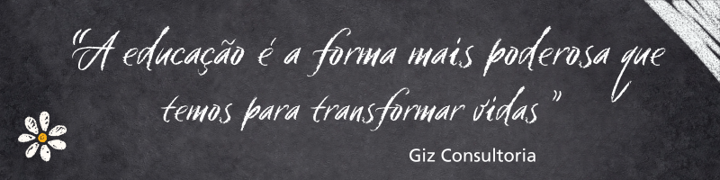

## Nosso Consultor

**Bruno Gasparotto Ponne** é Mestre em Políticas Públicas pela Hertie School de Berlim, com experiência em análise de programas governamentais e monitoramento de indicadores. Assessor Parlamentar no Senado Federal com experiência na formulação e tramitação de projetos de lei e na análise de dados para para assessorar legisladores. Na GIZ, Bruno transforma dados em recomendações e ações capazes de mudar a realidade da educação.

## Sobre a GIZ

### História

A GIZ Consultoria surge a partir de algo em comum entre dois amigos: a crença de que a educação é a forma mais poderosa que temos para transformar vidas.

Com mais de 10 anos de experiência no Senado Federal, nosso contato com líderes municipais, nossa pesquisa e análise das mais diversas fontes de dados, percebemos uma infinidade de oportunidades de melhoria para a educação pública.

Inspirados por essas vivências, acreditamos que, com muita dedicação, planejamento e uma boa dose de criatividade é possível oferecer uma educação pública de qualidade às crianças e jovens brasileiros.

A partir de inúmeras conversas sobre como poderíamos ajudar os municípios a melhorar os seus indicadores educacionais com os recursos possíveis nasce a GIZ, empresa de consultoria e assessoria que busca a excelência nos serviços oferecidos.

Mais do que um trabalho, a GIZ tem um propósito: transformar vidas através da educação.

### Missão

A GIZ Consultoria surge com a missão de oferecer assessoria de excelência para promover uma educação pública de qualidade, por meio do uso de dados, diagnósticos, planos de ação e otimização dos recursos públicos.

### Visão

Nossa visão é ser a empresa número um em assessoria para líderes municipais que buscam construir uma educação pública de qualidade.

### Valores

Nossos valores são a gestão eficiente, a inovação e o zelo pela coisa pública.

## Contato

Entre em contato conosco para planejarmos o futuro da educação do seu Município:

Bruno Gasparotto Ponne E-mail: bruno.ponne@gizeducacao.com.br

Luciano Nascimento E-mail: luciano@gizeducacao.com.br

Telefone para contato: (61) 9 9287-3790